# Sorting Visualizer

A Blog On Sorting Algorithms

# Merge Sort

**Time Complexity:** Sorting arrays on different machines. Merge Sort is a recursive algorithm and time complexity can be expressed as following recurrence relation.  
T(n) = 2T(n/2) + θ(n)

The above recurrence can be solved either using the Recurrence Tree method or the Master method. It falls in case II of Master Method and the solution of the recurrence is θ(nLogn). Time complexity of Merge Sort is θ(nLogn) in all 3 cases (worst, average and best) as merge sort always divides the array into two halves and takes linear time to merge two halves.  
**Auxiliary Space:** O(n)  
**Algorithmic Paradigm:** Divide and Conquer  
**Sorting In Place:** No in a typical implementation  
**Stable:** Yes

**Applications of Merge Sort**

1. Merge Sort is useful for sorting linked lists in O(nLogn) time.In the case of linked lists, the case is different mainly due to the difference in memory allocation of arrays and linked lists. Unlike arrays, linked list nodes may not be adjacent in memory. Unlike an array, in the linked list, we can insert items in the middle in O(1) extra space and O(1) time. Therefore, the merge operation of merge sort can be implemented without extra space for linked lists.  
   In arrays, we can do random access as elements are contiguous in memory. Let us say we have an integer (4-byte) array A and let the address of A[0] be x then to access A[i], we can directly access the memory at (x + i*4). Unlike arrays, we can not do random access in the linked list. Quick Sort requires a lot of this kind of access. In a linked list to access i’th index, we have to travel each and every node from the head to i’th node as we don’t have a continuous block of memory. Therefore, the overhead increases for quicksort. Merge sort accesses data sequentially and the need of random access is low.
2. Inversion Count Problem
3. Used in External Sorting

[figure not shown]

## Example 2

[figure not shown]

**In python there's an inbuilt method named "sorted()" or "sort()" which sorts the elements directly,this method uses a very hybrid algorithm known as `TIM SORT`,which is derived using the concepts of `merge sort` and `insertion sort` and merge sort is very useful and performs well when the size of the list is very large,it doesn't perform well when the size of the list is small,when the size is small,merge sort works very slow,coz of recursion,so in case of lists having small size,merge sort uses insertion sort as an handy guy to sort,why insertion?,coz insertion sort is also stable,i.e duplicate elements are preserved!!,and order also,and also insertion sort can be implemented using `linked lists` as well and merge sort works well with linked lists rather than `array's` so that's the reason why merge sort and insertion sort are used in the derivation of TIM SORT!!,`TIM SORT` time complexities:**

BEST CASE:O(n)

AVG CASE:O(nlogn)

WORST CASE:O(nlogn)

### Merging 2 sorted lists!

**As you can see ↓ that i've defined 4 test cases,one in which the len(a)==len(b),the other is len(a)<len(b),the other is len(a)>len(b) and the last one is there is a common element in both the lists!!,so in case of merging,the duplication is allowed and that's the speciality of this,as merge sort will use merging and merging is used in external sorting,merge so merge sort will also use external sorting,in real time secnario's we will definetly get duplicate elements,but their use/importance must be preserved,like for ex in a student's database!,the marks of more than 2 students can be same,that doesn't mean that we have to choose only 1,we need all the marks even though the marks are same,but the names/id of student is different!!,that's where merge sort helps,it is stable and allows duplicacy!,as shown in test case 4 below ↓,note: we cannot use the `zip()` method,coz that is possible only when the len(a)==len(b) and in most of the cases sizes of lists are not used,so we don't use them!!**

```python
def merge_sorted_lists(a,b):
    j = 0
    result = []
    for i in range(len(a)):
        if a[i]<=b[j]:
            result.append(a[i])
        else:
            result.append(a[j])
            j+=1

        ## if all the elements of 'b' are done,then transfer
        ## the left over elements of 'a' in the result set

        if j>len(b):
            result.append(a[i])

    ## all the elements of 'a' are done,remaining are 'b',append them
    remain_list = b[j:]
    for i in remain_list:
        result.append(i)

    return result

t = int(input())
while t:
    list1 = list(map(int,input().split()))
    list2 = list(map(int,input().split()))
    res = merge_sorted_lists(list1,list2)
    print(res)
    t-=1
```

```
4
1 2 3 4
5 6 7 8
[1, 2, 3, 4, 5, 6, 7, 8]
1 2 3
4 5 6 8
[1, 2, 3, 4, 5, 6, 8]
1 2 3 4
5 6
[1, 2, 3, 4, 5, 6]
1 2 3
3 4 5
[1, 2, 3, 3, 4, 5]
```

## MERGE SORT

```python
## TC = O(nlogn)
## SC = O(logn)
## algo:
       '''
       low = 0
       high = len(arr)-1
       if low<high:
           mid = (low+high)//2
           merge(low,mid)------------>T(n/2)
           merge(mid+1,high)--------->T(n/2)
           merge_list(low,mid,high)-->n
           --------------------------------
           Total_time = T(n)=T(n/2)+T(n/2)+n==2T(n/2)+n

       recurence_reltion = T(n) {
                                        1 if n=1
                                        2T(n/2)+n if n>1
       }
       '''

def merge_sorted_lists(a,b,arr):
    len_a = len(a)
    len_b = len(b)

    i = j = k = 0

    while i < len_a and j < len_b:
        if a[i] <= b[j]:
            arr[k] = a[i]
            i+=1
        else:
            arr[k] = b[j]
            j+=1
        k+=1

    while i < len_a:
        arr[k] = a[i]
        i+=1
        k+=1

    while j < len_b:
        arr[k] = b[j]
        j+=1
        k+=1

def mergesort(arr):

    if len(arr) <= 1:
        return

    mid = len(arr)//2

    left = arr[:mid]
    right = arr[mid:]

    mergesort(left)
    mergesort(right)

    merge_sorted_lists(left, right, arr)

t = int(input())
while t:
    list1 = list(map(int,input().split()))
    mergesort(list1)
    print(list1)
    t-=1
```

```
2
2 3 6 5 4 7 8 9
[2, 3, 4, 5, 6, 7, 8, 9]
3 6 5 4 78 1 2
[1, 2, 3, 4, 5, 6, 78]
```

### Merge Sort Exercise

```
elements = [
        { 'name': 'vedanth',   'age': 17, 'time_hours': 1},
        { 'name': 'rajab', 'age': 12,  'time_hours': 3},
        { 'name': 'vignesh',  'age': 21,  'time_hours': 2.5},
        { 'name': 'chinmay',  'age': 24,  'time_hours': 1.5},
    ]
```

merge_sort function should take key from an athlete's marathon log and sort the list as per that key. For example,

```
merge_sort(elements, key='time_hours', descending=True)
```

This will sort elements by time_hours and your sorted list will look like,

```
elements = [
        {'name': 'rajab', 'age': 12, 'time_hours': 3},
        {'name': 'vignesh', 'age': 21, 'time_hours': 2.5},
        {'name': 'chinmay', 'age': 24, 'time_hours': 1.5},
        {'name': 'vedanth', 'age': 17, 'time_hours': 1},
    ]
```

But if you call it like this,

```
merge_sort(elements, key='name')
```

output will be,

```
elements = [
        { 'name': 'chinmay',   'age': 24, 'time_hours': 1.5},
        { 'name': 'rajab', 'age': 12,  'time_hours': 3},
        { 'name': 'vedanth',  'age': 17,  'time_hours': 1},
        { 'name': 'vignesh',  'age': 21,  'time_hours': 2.5},
    ]
```

```python
def merging(a,b,arr):
    i=j=k=0
    while i<len(a) and j<len(b):
        if a[i]<=b[j]:
            arr[k] = a[i]
            i+=1
        else:
            arr[k] = b[j]
            j+=1
        k+=1

    while i<len(a):
        arr[k] = a[i]
        i+=1
        k+=1
    while j<len(b):
        arr[k] = b[j]
        j+=1
        k+=1

def me_sort(arr,key):

    if len(arr)<=1:
        return

    mid = len(arr)//2

    left = arr[:mid]
    right = arr[mid:]


    me_sort(left,key)
    me_sort(right,key)

    merging(left,right,arr)


elements = [
        { 'name': 'vedanth',   'age': 17, 'time_hours': 1},
        { 'name': 'rajab', 'age': 12,  'time_hours': 3},
        { 'name': 'vignesh',  'age': 21,  'time_hours': 2.5},
        { 'name': 'chinmay',  'age': 24,  'time_hours': 1.5},
    ]

key = input()
to_pass = []

for i in range(len(elements)):
    to_pass.append(elements[i][key])

me_sort(to_pass,key)
result = to_pass


## converting a list of dictionaries to dictionary of dictionaries

new_dict = {item['name']:item for item in elements}
new_dict

## sorting a dictionary according to a specific key!! very very important trick

res = sorted(new_dict.items(),key = lambda x:x[1][key])
print(res)

print('\n\n')

print(result)
```

```
name
[('chinmay', {'name': 'chinmay', 'age': 24, 'time_hours': 1.5}), ('rajab', {'name': 'rajab', 'age': 12, 'time_hours': 3}), ('vedanth', {'name': 'vedanth', 'age': 17, 'time_hours': 1}), ('vignesh', {'name': 'vignesh', 'age': 21, 'time_hours': 2.5})]



['chinmay', 'rajab', 'vedanth', 'vignesh']
```

# Quick Sort

**Quick Sort uses Divide and Conquer Technique,here we select the first element as the pivot element and then try to place that pivot element in it's sorted place,when that element is placed at it's sorted place we observe that elements less than the pivot are at the left and elements greater than picot are at the right,so we recursilvey call the algorithm on left side and on the right side,so by that every element will get it's sorted position and we finally get the sorted array/list!!,so this is how quick sort works,we find the sorted position of all teh elements and sort the list,it uses 2 logics one is the partioning and other is merging,the partioning,there are 2 pointer,low and high,so we keep on incrementing low unitl we find a elemnt greater than pivot,and keep on decrementing high until we find a element less than pivot,once we find those elements,we swap them,and follow the recursion,the main disadvantage of this is the selection of pivot,always pivot must be randomly selected,i.e one should not select the pivot as the starting element,coz there are cases where the algorithm will take O(n²) time not O(nlogn) time,so inorder to maintain O(nlogn),Quick sort is Quick and is an inplace algorthim,it works well with small and medium size lists,however merge sort works well with large size lists,**

**QuickSort is a Divide and Conquer algorithm. It picks an element as pivot and partitions the given array around the picked pivot. There are many different versions of quickSort that pick pivot in different ways.**

1. Always pick first element as pivot.
2. Always pick last element as pivot
3. Pick a random element as pivot.
4. Pick median as pivot.

**The key process in quickSort is partition(). Target of partitions is, given an array and an element x of array as pivot, put x at its correct position in sorted array and put all smaller elements (smaller than x) before x, and put all greater elements (greater than x) after x. All this should be done in linear time.**

**Pseudo Code for recursive QuickSort function :**

```
/* low  --> Starting index,  high  --> Ending index */
quickSort(arr[], low, high)
{
    if (low < high)
    {
        /* pi is partitioning index, arr[pi] is now
           at right place */
        pi = partition(arr, low, high);

        quickSort(arr, low, pi - 1);  // Before pi
        quickSort(arr, pi + 1, high); // After pi
    }
}
```

**There're 2 partition schemes,one is Hoare partition and another is Lomatu partition,in hoare partition what we do is,we select the 1st element as the pivot element,then we keep a low pointer pointing at the start index and the high pointer pointing at the last index,now we keep on comparing the elements with the pivot,i.e we keep on increment low,until we get a value greater than pivot,once we get we stop,then we keep on decrementing high until we get a value which is smaller than pivot,once we get we stop,now when we stop we have low pointing to a value > pivot and high poniting to a value < pivot,now we swap low and high,i,e swap(low,high) and then continue the similar process until we reach a condition when low crosses high!!,once low crossed high we stop and swap pivot with high,i,e swap(pivot,high),when we do that we observe that we got the pivot at it's sorted position!!,and all the elements on the left of the pivot are smaller and on the right of pivot are greater,so this is Hoare scheme,this is very popular**

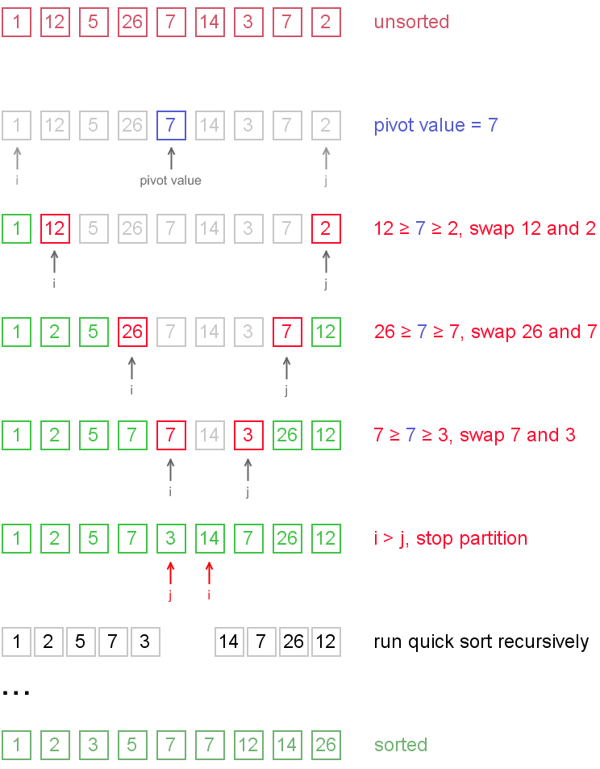

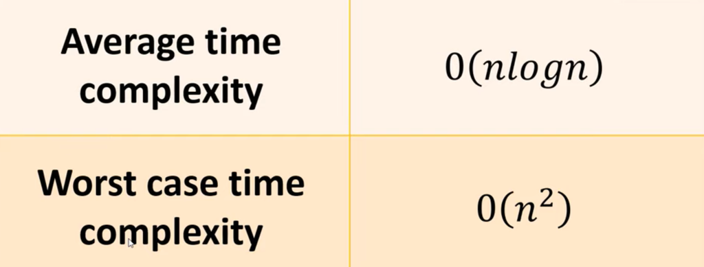

```python
def quick_sort(elements, start, end):
    if start < end:
        pi = partition(elements, start, end)
        quick_sort(elements, start, pi-1)
        quick_sort(elements, pi+1, end)

def partition(elements, start, end):
    pivot_index = start
    pivot = elements[pivot_index]

    while start < end:
        while start < len(elements) and elements[start] <= pivot:
            start+=1

        while elements[end] > pivot:
            end-=1

        if start < end:
            elements[start],elements[end] = elements[end],elements[start]

    elements[pivot_index],elements[end] = elements[end],elements[pivot_index]
    return end


t = int(input())
while t:
    list1 = list(map(int,input().split()))
    quick_sort(list1,0,len(list1)-1)
    print(list1)
    t-=1
```

```
1
2 3 6 5 4 1
[1, 2, 3, 4, 5, 6]
```

# Insertion Sort

Insertion sort is a simple sorting algorithm that works similar to the way you sort playing cards in your hands. The array is virtually split into a sorted and an unsorted part. Values from the unsorted part are picked and placed at the correct position in the sorted part.

**Algorithm**  
To sort an array of size n in ascending order:  
1: Iterate from arr[1] to arr[n] over the array.  
2: Compare the current element (key) to its predecessor.  
3: If the key element is smaller than its predecessor, compare it to the elements before. Move the greater elements one position up to make space for the swapped element.

**Example:**

[figure not shown]

**Another Example:**  
**12**, 11, 13, 5, 6

Let us loop for i = 1 (second element of the array) to 4 (last element of the array)

i = 1. Since 11 is smaller than 12, move 12 and insert 11 before 12  
**11, 12**, 13, 5, 6

i = 2. 13 will remain at its position as all elements in A[0..I-1] are smaller than 13  
**11, 12, 13**, 5, 6

i = 3. 5 will move to the beginning and all other elements from 11 to 13 will move one position ahead of their current position.  
**5, 11, 12, 13**, 6

i = 4. 6 will move to position after 5, and elements from 11 to 13 will move one position ahead of their current position.  
**5, 6, 11, 12, 13**

**suppose you've an list like : [21,38,29,17,4,25,11,32,9] now you need to sort this list using insertion sort,so what we do is we take an empty list name it as "sorted",so sorted = [],now we select the 1st element of the list(unsorted one) i.e 21 we add 21 to the sorted list i.e [21],now the next element is 38,we add that in the sorted list such that the sorted list remains "sorted" so the list becomes [21,38],then the next element is 29,so you cannot insert 29 at the end,as the list becomes unsorted,so you've to insert it in the middle so th list is : [21,29,38],now the next element is 17,so you'll compare 17 with the elements from the begining and place it in the correct position,so the array becomes: [17,21,29,38] like that keep on inserting the elements in the array**

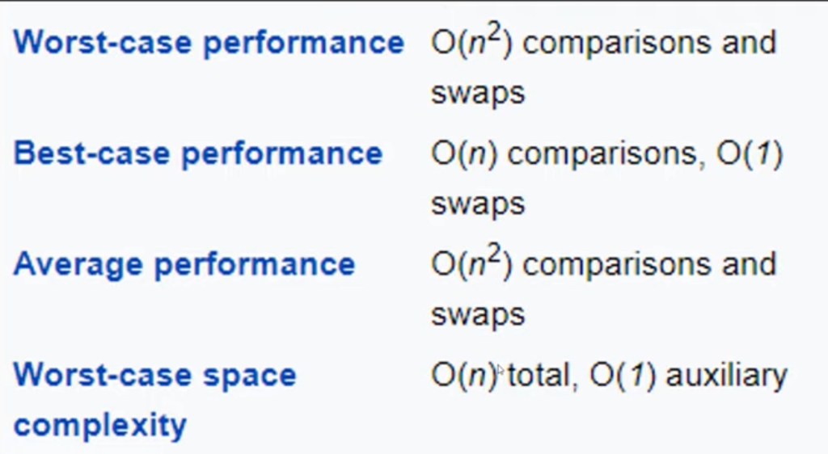

```python
'''
The trick is we'll start with the index 1,not with index0,coz we're assuming
that a single element list is sorted,as in the LHS we'll be having
element with idx0,that's sorted,so we'll insert the elements from the RHS
to the LHS,in such a way that it is sorted!!

'''

def insertion(elements):
    for i in range(1,len(elements)):
        anchor = elements[i]

        j = i-1   # one less than cuurent element

        while(j>=0 and anchor<elements[j]):
            elements[j+1] = elements[j]
            j-=1
        elements[j+1] = anchor


t = int(input())
while t:
    list1 = list(map(int,input().split()))
    insertion(list1)
    print(list1)
    t-=1
```

```
1
2 3 6 5 8 9
[2, 3, 5, 6, 8, 9]
```

```python
job_list = list(map(str,input().split()))
profit_list = list(map(int,input().split()))
wait_list = list(map(int,input().split()))
min_time,max_time = min(wait_list),max(wait_list)
job_dict = dict(zip(job_list,profit_list))
time_dict = dict(zip(profit_list,wait_list))
print(f' job dict is {job_dict},\n\n time dict is {time_dict}')

# reverse=True will sort the values in decending order

job_dict = sorted(job_dict.items(),key=lambda x:x[1],reverse = True)
time_dict = sorted(time_dict.items(),key=lambda x:x[0],reverse=True)

print('\n')

print(f' job dict is {job_dict},\n\n time dict is {time_dict}')


job_to_do = [0]*max_time
j = 0
for i in range(1,len(time_dict)):
    idx = time_dict[i][1]
    if job_to_do[idx]==0:
            job_to_do[idx] = time_dict[i][1]
    if job_to_do[idx-1]==0:
        job_to_do[idx-1] = time_dict[i][1]
```

```
j1 j2 j3 j4 j5
20 15 10 5 1
2 2 1 3 3
 job dict is {'j1': 20, 'j2': 15, 'j3': 10, 'j4': 5, 'j5': 1},

 time dict is {20: 2, 15: 2, 10: 1, 5: 3, 1: 3}


 job dict is [('j1', 20), ('j2', 15), ('j3', 10), ('j4', 5), ('j5', 1)],

 time dict is [(20, 2), (15, 2), (10, 1), (5, 3), (1, 3)]
```

[output not shown]

```python
job_to_do = [0]*max_time
job_to_do
```

```
[0, 0, 0]
```

```python
time_dict[2][1]
```

```
1
```

# Heap Sort

Heap is a special tree-based data structure. A binary tree is said to follow a heap data structure if:

- it is a complete binary tree
- All nodes in the tree follow the property that they are greater than their children i.e. the largest element is at the root and both its children and smaller than the root and so on. Such a heap is called a max-heap. If instead, all nodes are smaller than their children, it is called a min-heap

[figure not shown]

## How to "heapify" a tree

Starting from a complete binary tree, we can modify it to become a Max-Heap by running a function called heapify on all the non-leaf elements of the heap.

Since heapify uses recursion, it can be difficult to grasp. So let's first think about how you would heapify a tree with just three elements.

[figure not shown]

The example above shows two scenarios - one in which the root is the largest element and we don't need to do anything. And another in which the root had a larger element as a child and we needed to swap to maintain max-heap property.

If you're worked with recursive algorithms before, you've probably identified that this must be the base case.

Now let's think of another scenario in which there is more than one level.

[figure not shown]

How to heapify root element when its subtrees are already max heaps

The top element isn't a max-heap but all the sub-trees are max-heaps.

To maintain the max-heap property for the entire tree, we will have to keep pushing 2 downwards until it reaches its correct position.

[figure not shown]

How to heapify root element when its subtrees are max-heaps

## Build max-heap

To build a max-heap from any tree, we can thus start heapifying each sub-tree from the bottom up and end up with a max-heap after the function is applied to all the elements including the root element.

In the case of a complete tree, the first index of a non-leaf node is given by n/2 - 1. All other nodes after that are leaf-nodes and thus don't need to be heapified.

So, we can build a maximum heap as

[figure not shown]

Steps to build max heap for heap sort

[figure not shown]

Steps to build max heap for heap sort

[figure not shown]

Steps to build max heap for heap sort

## How Heap Sort Works?

1. Since the tree satisfies Max-Heap property, then the largest item is stored at the root node.
2. **Swap:** Remove the root element and put at the end of the array (nth position) Put the last item of the tree (heap) at the vacant place.
3. **Remove:** Reduce the size of the heap by 1.
4. **Heapify:** Heapify the root element again so that we have the highest element at root.
5. The process is repeated until all the items of the list are sorted.

[figure not shown]

Swap, Remove, and Heapify

```python
import time

def heapsort(elements):

    ans = []

    while(len(ans)!=len(elements)):

        max_ele = max(elements)

        max_idx = elements.index(max(elements))

        elements[max_idx] = 0

        ans.append(max_ele)

    return ans

number_list = list(map(int,input().split()))

#t0 = time.time()

ans = heapsort(number_list)

t1 = time.time()


print(f' Desecending order sort ans :{ans}')

print(f' Ascending order sort ans : {ans[::-1]}')

print(f' Time Taken to Sort is {t1}')
```

[output not shown]

```python
t0
```

[output not shown]

```python
t1
```

[output not shown]

## BST sort

[figure not shown]

```python
class bst:

    def __init__(self,data):
        self.data = data
        self.left = None
        self.right = None



    def insert(self,data):

        ## allows no duplicates

        if self.data==data:
            return

        if self.data>data:
            if self.left:
                self.left.insert(data)

            else:
                self.left = bst(data)
        else:
            if self.right:
                self.right.insert(data)
            else:
                self.right = bst(data)

    def inorder(self):

        ans = []

        if self.left:
            ans+=self.left.inorder()

        ans.append(self.data)

        if self.right:
            ans+=self.right.inorder()


        return ans


    def preorder(self):

        ans = []

        ans.append(self.data)

        if self.left:
            ans+=self.left.preorder()

        if self.right:

            ans+=self.right.preorder()

        return ans
```

```python
def working(elements):

    root = bst(elements[0])

    for i in range(1,len(elements)):

        root.insert(elements[i])

    return root


number_list = list(map(int,input().split()))


root = working(number_list)

ans = root.inorder()


t1 = time.time()


print(f' Ascending order sort ans :{ans}')

print(f' Descending order sort ans : {ans[::-1]}')

print(f' Time Taken to Sort is {t1}')
```

[output not shown]